# final_project

```python
### Gilmore girls data Analysis

link to csv: https://drive.google.com/file/d/1X4joMQ27EkiTYKfpPZjgrlU6VYXl19HL/view?usp=sharing
```

### Introduction to data set

The original data set only included the -Character -Line -Season

From our own knowledge about the characters other columns were added like: -Gender -Job -Age

```python
import pandas as pd
import seaborn as sns
import matplotlib.pyplot as plt
from sklearn import linear_model, model_selection, metrics
from sklearn.linear_model import Ridge
from sklearn.model_selection import train_test_split
from sklearn.metrics import mean_squared_error, r2_score
import numpy as np
df = pd.read_csv("Gilmore_Girls_Lines_Updated.csv")
display(df)
```

|  | Unnamed: 0 | Character | Line | Season | Gender | Job | Character Traits | Age | Lines in Season | Seasons Appeared | Lines per Season | Relevance Score |
| --- | --- | --- | --- | --- | --- | --- | --- | --- | --- | --- | --- | --- |
| 0 | 0 | Lorelai | Please, Luke. Please, please, please. | 1 | Female | Inn Owner | Sarcastic, Independent | 32 | 4230.0 | 7.0 | 604.285714 | 604.285714 |
| 1 | 1 | Luke | How many cups have you had this morning? | 1 | Male | Diner Owner | Grumpy, Loyal | 40 | 868.0 | 7.0 | 124.000000 | 124.000000 |
| 2 | 2 | Lorelai | None. | 1 | Female | Inn Owner | Sarcastic, Independent | 32 | 4230.0 | 7.0 | 604.285714 | 604.285714 |
| 3 | 3 | Luke | Plus... | 1 | Male | Diner Owner | Grumpy, Loyal | 40 | 868.0 | 7.0 | 124.000000 | 124.000000 |
| 4 | 4 | Lorelai | Five, but yours is better. | 1 | Female | Inn Owner | Sarcastic, Independent | 32 | 4230.0 | 7.0 | 604.285714 | 604.285714 |
| ... | ... | ... | ... | ... | ... | ... | ... | ... | ... | ... | ... | ... |
| 107421 | 115200 | Rory | Well It wasn't very flattering. | 7 | Female | Student, Journalist | Ambitious, Bookish | 16 | 2828.0 | 7.0 | 404.000000 | 404.000000 |
| 107422 | 115201 | Lorelai | Well how will people know you're the world's g... | 7 | Female | Inn Owner | Sarcastic, Independent | 32 | 3901.0 | 7.0 | 557.285714 | 557.285714 |
| 107423 | 115202 | Rory | I don't know. | 7 | Female | Student, Journalist | Ambitious, Bookish | 16 | 2828.0 | 7.0 | 404.000000 | 404.000000 |
| 107424 | 115203 | Lorelai | I guess they'll just have to read your stuff. | 7 | Female | Inn Owner | Sarcastic, Independent | 32 | 3901.0 | 7.0 | 557.285714 | 557.285714 |
| 107425 | 115204 | Rory | I guess so. | 7 | Female | Student, Journalist | Ambitious, Bookish | 16 | 2828.0 | 7.0 | 404.000000 | 404.000000 |

107426 rows × 12 columns

### Hypothesis generation and exploration

#### 1. Does Gender effect relevance?

#### 2. Which characters spoke the most?

#### 3. Did some characters get less or more relevant as the seasons went on?

#### 4. Does the age of the characters have an effect on relevance?

#### 5. Common words/statements? What are the most common phrases, who are they said by?

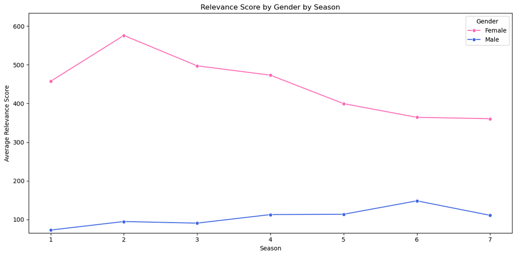

```python
# Plot 1: Does Gender effect relevance as the seasons go on?
gender_season_relevance = df.groupby(['Gender', 'Season'])['Relevance Score'].mean().reset_index()

plt.figure(figsize=(12, 6))
sns.lineplot(
    data=gender_season_relevance,
    x='Season',
    y='Relevance Score',
    hue='Gender',
    marker='o',
    palette={'Female': 'hotpink', 'Male': 'royalblue'}
)

plt.title("Relevance Score by Gender by Season")
plt.xlabel("Season")
plt.ylabel("Average Relevance Score")
plt.ylim(gender_season_relevance['Relevance Score'].min() * 0.9,
         gender_season_relevance['Relevance Score'].max() * 1.1)  # zoom in
plt.legend(title='Gender')
plt.tight_layout()
plt.show()
```

Looks like in general, the female characters in this show have way more relevance than the male characters, this makes sense considering our main characters are 3 generations of women, most of their friends are women. Interestingly, the male charaters steadily gain more relevance, peaking in season 6. The female characters seem to drop down in relevance after season 2, this could be due to:

-Female Lead Saturation: By Season 2, the central female characters—Lorelai, Rory, and Emily—had firmly established their roles. The show's early seasons heavily centered on their lives, building strong arcs. After that, the focus began to diversify.

-Luke’s storyline deepens, especially with his relationship with Lorelai and the reveal of his daughter. Logan, Jess, and Dean become central figures in Rory’s romantic life.

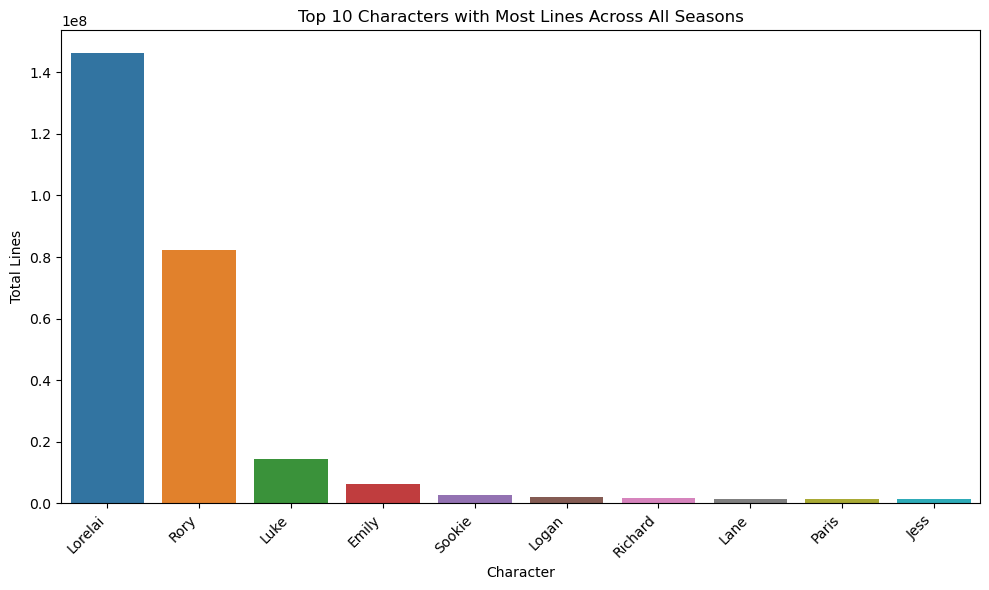

```python
# Plot 2: Who talks the most overall?
top_characters = df.groupby('Character')['Lines in Season'].sum().sort_values(ascending=False).head(10)

plt.figure(figsize=(10, 6))
sns.barplot(x=top_characters.index, y=top_characters.values, hue=top_characters.index, legend="auto")
plt.xticks(rotation=45, ha='right')
plt.title("Top 10 Characters with Most Lines Across All Seasons")
plt.xlabel("Character")
plt.ylabel("Total Lines")
plt.tight_layout()
plt.show()
```

### Most Chatty:

No surprise there, Lorelai in particular is known to talk vert fast. Actress said that once the writers figured out she could memorise a lot of lines quickly, they would often give her long winded sentences. Rory is a close second, since most of the show is her interacting with her mom, this makes sense. Luke is third, which is probably due to the fact that he is there consistently in the show from the very first episode to the last, often having to interact with both Loerlai and Rory who often frequent is diner and ask him for help in certain situations. Interestingly enough, Dean, Rory's first boyfriend who was also a fan favorite did not make it in the top talkative characters, but Logan and Jess did!

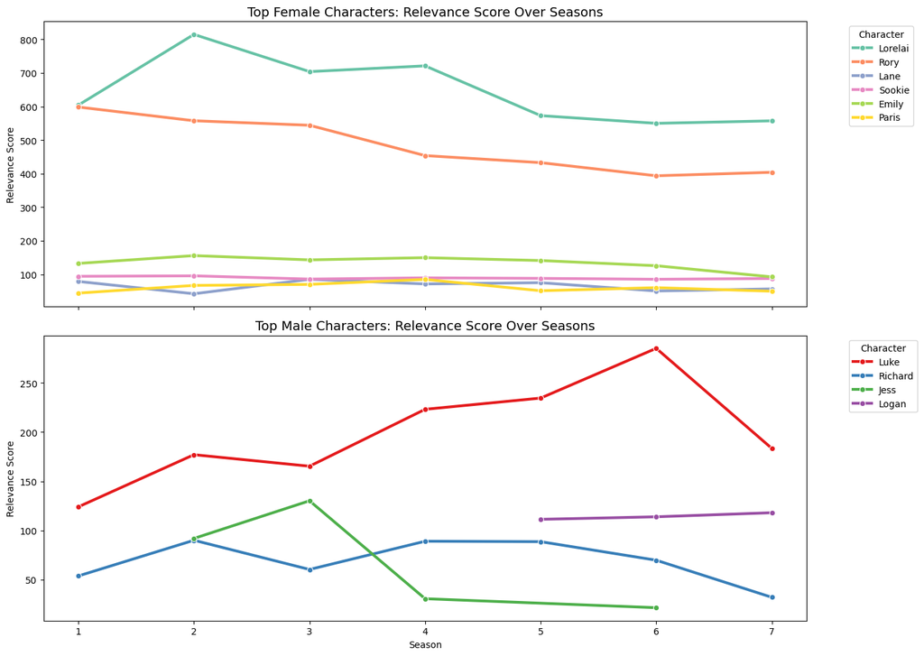

```python
# Plot 3: How did the overall relevance of different characters change as the seasons progress?

top_characters = df.groupby('Character')['Lines in Season'].sum().sort_values(ascending=False).head(10).index.tolist()

df_top = df[df['Character'].isin(top_characters)]

df_female = df_top[df_top['Gender'] == 'Female']
df_male = df_top[df_top['Gender'] == 'Male']

female_characters = df_female['Character'].unique()
male_characters = df_male['Character'].unique()

female_palette = sns.color_palette("Set2", len(female_characters))
male_palette = sns.color_palette("Set1", len(male_characters))

fig, axes = plt.subplots(2, 1, figsize=(14, 10), sharex=True)

# Female Plot
sns.lineplot(data=df_female, x='Season', y='Relevance Score', hue='Character',
             linewidth=3, palette=dict(zip(female_characters, female_palette)), ax=axes[0], marker='o')
axes[0].set_title("Top Female Characters: Relevance Score Over Seasons", fontsize=14)
axes[0].set_ylabel("Relevance Score")
axes[0].legend(title='Character', bbox_to_anchor=(1.05, 1), loc='upper left')

# Male Plot
sns.lineplot(data=df_male, x='Season', y='Relevance Score', hue='Character',
             linewidth=3, palette=dict(zip(male_characters, male_palette)), ax=axes[1], marker='o')
axes[1].set_title("Top Male Characters: Relevance Score Over Seasons", fontsize=14)
axes[1].set_xlabel("Season")
axes[1].set_ylabel("Relevance Score")
axes[1].legend(title='Character', bbox_to_anchor=(1.05, 1), loc='upper left')

plt.tight_layout()
plt.show()
```

### Relevance explanation:

Sookie, Emily, Lane and Paris seem to have a consistent relevance as the series developes, so the biggest contribution to the female relevance decreasing is Lorelai and Rory. This makes sense, as the male story lines like Lukes and Richards develope more, there is less room for Lorealai and Rory to speak. Also Rory moving away for college limits her intercations with her mom and town friends which are mostly female friendships.

It appears Luke contributes the most to the male characters becoming more relevant. Jess having a sharp decrease makes sense since he left the town, as well as Logan being consitently present as Rory's boyfriend in the last 3 seasons.

New Male-Centric Subplots: By Season 6, multiple episodes explore male character perspectives or subplots more deeply (e.g., Luke’s parenting challenges, Logan’s business ventures), pulling narrative weight away from Lorelai and Rory's speaking time.

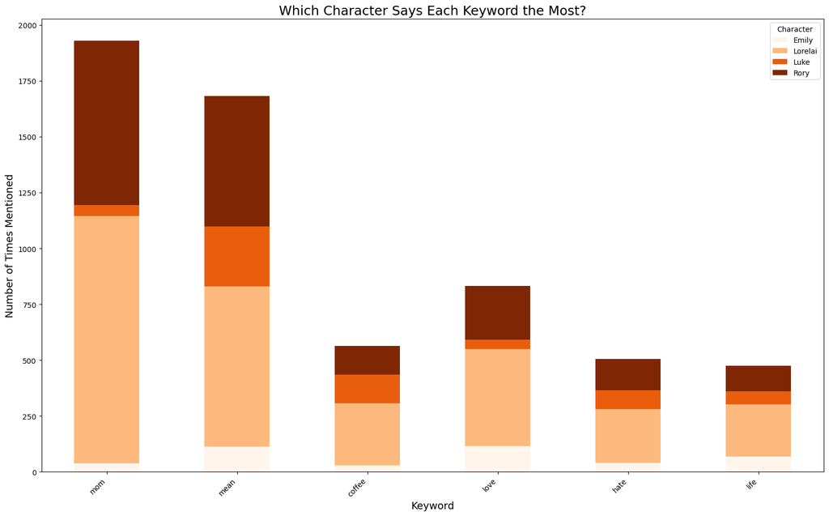

```python
import pandas as pd
import matplotlib.pyplot as plt

# ---------------------------------
# Seeing how often common words were said in the course of the whole show

# Common words I'm interested in
keywords = ['mom', 'mean', 'coffee', 'love', 'hate', 'life']

# Drop NaNs and make all lines lowercase
df['Line'] = df['Line'].dropna().astype(str).str.lower()

# Only focus on top 4 characters
top_chars = ['Lorelai', 'Rory', 'Luke', 'Emily']
df_filtered = df[df['Character'].isin(top_chars)].copy()

# Count how many times each character says each keyword
keyword_counts = {}

for word in keywords:
    # <- fix here: add na=False
    counts = (
        df_filtered[df_filtered['Line'].str.contains(word, regex=False, na=False)]
        .groupby('Character')
        .size()
    )
    keyword_counts[word] = counts

# Create a DataFrame
keyword_counts_df = pd.DataFrame(keyword_counts).fillna(0).astype(int)

# Transpose for easier plotting (optional)
keyword_counts_df = keyword_counts_df.T

# Plot
plt.figure(figsize=(16, 10))
keyword_counts_df.plot(kind='bar', stacked=True, colormap='Oranges', figsize=(16,10))

plt.title('Which Character Says Each Keyword the Most?', fontsize=18)
plt.xlabel('Keyword', fontsize=14)
plt.ylabel('Number of Times Mentioned', fontsize=14)
plt.legend(title='Character')
plt.xticks(rotation=45, ha='right')
plt.tight_layout()
plt.show()
```

Words like “mom”, “love”, and “coffee” were used most often by Lorelai, reflecting her central role as a fast-talking, emotionally expressive character who often references her family and routines (especially coffee).

Luke’s keyword use includes more grounded or conflict-related terms like “mean” and “coffee”, matching his character as the diner owner and frequent voice of sarcasm or reason.

```
✅ RMSE: 3.86
✅ R² Score: 0.8976
✅ Training R² Score: 0.9241
```

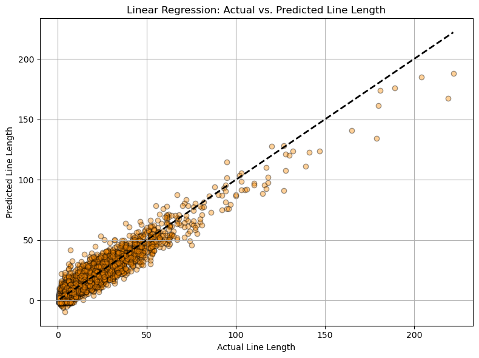

```python
import pandas as pd
import matplotlib.pyplot as plt
from sklearn.linear_model import LinearRegression
from sklearn.metrics import mean_squared_error, r2_score
from sklearn.preprocessing import LabelEncoder
from sklearn.model_selection import train_test_split
from sklearn.feature_extraction.text import TfidfVectorizer
from scipy.sparse import hstack
from collections import Counter
import numpy as np

# Ensure Line is valid text
df_filtered = df_filtered.copy()
df_filtered['Line'] = df_filtered['Line'].astype(str).str.strip()
df_filtered = df_filtered[df_filtered['Line'] != '']

# Recalculate clean features
def count_repetitions(line):
    words = line.lower().split()
    word_count = Counter(words)
    return sum(count > 1 for count in word_count.values())

df_filtered['line_length'] = df_filtered['Line'].apply(lambda x: len(x.split()))
df_filtered['repetition_count'] = df_filtered['Line'].apply(count_repetitions)

# Drop rows with impossible or invalid values
df_filtered = df_filtered[
    (df_filtered['line_length'] > 0) &
    (df_filtered['repetition_count'] >= 0)
]

# Encode character
le = LabelEncoder()
df_filtered['char_encoded'] = le.fit_transform(df_filtered['Character'])

# TF-IDF
vectorizer = TfidfVectorizer(min_df=5, max_df=0.8, stop_words='english')
X_text = vectorizer.fit_transform(df_filtered['Line'])

# Combine features
X_other = df_filtered[['char_encoded', 'Season', 'repetition_count']].values
X = hstack([X_text, X_other])
y = df_filtered['line_length']

# Train-test split
X_train, X_test, y_train, y_test = train_test_split(X, y, test_size=0.2, random_state=42)

# Linear Regression
lr = LinearRegression()
lr.fit(X_train, y_train)
y_pred = lr.predict(X_test)

# Metrics
rmse = np.sqrt(mean_squared_error(y_test, y_pred))
r2 = r2_score(y_test, y_pred)

print("✅ RMSE:", round(rmse, 2))
print("✅ R² Score:", round(r2, 4))

train_r2 = lr.score(X_train, y_train)
print("✅ Training R² Score:", round(train_r2, 4))

# Plot
plt.figure(figsize=(8, 6))
plt.scatter(y_test, y_pred, alpha=0.4, color='darkorange', edgecolors='black')
plt.plot([y_test.min(), y_test.max()], [y_test.min(), y_test.max()], 'k--', lw=2)
plt.xlabel("Actual Line Length")
plt.ylabel("Predicted Line Length")
plt.title("Linear Regression: Actual vs. Predicted Line Length")
plt.grid(True)
plt.tight_layout()
plt.show()
```

#### Results of predicting line length

These results suggest that the model performs very well, explaining about 90% of the variation in line length on unseen test data. The relatively small difference between the training and testing R² scores indicates low overfitting, meaning the model generalizes well.

The low RMSE (average prediction error of around 4 words) is also impressive given the variability in character dialogue styles. This performance validates the strength of TF-IDF features in capturing textual patterns and supports the idea that line length is strongly associated with word content, speaker identity, and some structural context (season and repetition).

This tells us that there is real predictive power in guessing how long a person speaks based on who they are, what season they are appearing in and the language they use.

```python
# Preciting chaarcter based on line length and repition count.
import pandas as pd
from sklearn.feature_extraction.text import TfidfVectorizer
from sklearn.model_selection import train_test_split
from sklearn.ensemble import RandomForestClassifier
from sklearn.metrics import accuracy_score, confusion_matrix
from sklearn.preprocessing import LabelEncoder
from scipy.sparse import hstack
from collections import Counter
import numpy as np

# Filter to top 4 characters
top_chars = ['Lorelai', 'Rory', 'Luke', 'Emily']
df_filtered = df[df['Character'].isin(top_chars)].copy()

# Drop NaN lines
df_filtered = df_filtered.dropna(subset=['Line'])

# Extra features: sentence length, repetition count
def count_repetitions(line):
    words = line.lower().split()
    word_count = Counter(words)
    return sum(count > 1 for count in word_count.values())

df_filtered['line_length'] = df_filtered['Line'].apply(lambda x: len(str(x).split()))
df_filtered['repetition_count'] = df_filtered['Line'].apply(lambda x: count_repetitions(str(x)))

# TF-IDF vectorization
vectorizer = TfidfVectorizer(max_features=1000, stop_words='english')
X_text = vectorizer.fit_transform(df_filtered['Line'])

# Combine TF-IDF with sentence length and repetition
X_other = df_filtered[['line_length', 'repetition_count']].values
X = hstack([X_text, X_other])

# Encode labels
le = LabelEncoder()
y = le.fit_transform(df_filtered['Character'])

# Train-test split
X_train, X_test, y_train, y_test = train_test_split(X, y, test_size=0.2, random_state=42)

# Train model
rf = RandomForestClassifier(random_state=42)
rf.fit(X_train, y_train)

# Predict and evaluate
y_pred = rf.predict(X_test)
print("Accuracy:", accuracy_score(y_test, y_pred))
print("Confusion Matrix:\n", confusion_matrix(y_test, y_pred))
print("Classes:", le.classes_)
```

```
Accuracy: 0.4703215456511125
Confusion Matrix:
 [[ 266  723   40  314]
 [ 150 4521  195 1480]
 [  52 1236  189  460]
 [ 101 2708  135 1767]]
Classes: ['Emily' 'Lorelai' 'Luke' 'Rory']
```

[figure not shown]

```python
y_pred = rf.predict(X_test)

# Create confusion matrix
cm = confusion_matrix(y_test, y_pred)
classes = le.classes_

# Plot heatmap
plt.figure(figsize=(8, 6))
sns.heatmap(cm, annot=True, fmt='d', cmap='Oranges', xticklabels=classes, yticklabels=classes, cbar=False)
plt.xlabel('Predicted Label')
plt.ylabel('True Label')
plt.title('Predicting Who Said a Line Based on Speech Patterns', fontsize=14)
plt.show()
```

### Evaluating Character Guessing model

Data is definitly overfitting for Loerali and Rory due to the amount of lines they have, also overlapping conversations and similar speaking styles between Lorelai and Rory show they often get mistaken for eachother.

Captures general speech style differences between the characters and that basic text features (word use, length, repetition) still carry meaningful signals about the speaker.

#### Ethical Considerations

Our dataset is derived from publicly available transcripts of the television show Gilmore Girls, which falls under the category of fictional, non-human subject data.

Respect for Persons: Since characters represent fictional personas, there's no direct harm to individuals.

Beneficence: The data is used for educational purposes, exploring dialogue structure and character traits with no foreseeable harm or exploitation.

Justice: All characters were treated fairly in feature engineering, even though only the top four (Lorelai, Rory, Luke, and Emily) were used for predictive modeling due to data imbalance.

Respect for Law and Public Interest: All modifications and analysis were done on publicly accessible materials, complying with copyright and fair use for academic purposes.

#### Conclusion

Through this project, we transformed a basic script dataset into a rich, structured dataset for analysis and machine learning. By adding features like line length, repetition, gender, and seasonality, we were able to better understand dialogue patterns and train a classifier to predict the speaking character.

While the model is not yet highly reliable for deployment, it reveals promising patterns. With further tuning and balancing, it could serve as a tool for script analysis, character study, or even dialogue generation.

This project highlights how simple TV data can become a compelling case study in NLP, classification, and interpretability.